# Pertemuan 4 - AR/MA

Abie Septian G1401231069

# MA(2)

## Pembangkitan Data

```r
# SEED
set.seed(1069)
white<-rnorm(300)
```

```r
# MA(2) Manual
ma2<-white[c(1,2)]

for(i in 3:300){
  ma2[i]<-white[i]+0.4*white[i-1]+0.6*white[i-2]
}
ma2
```

```
##   [1] -1.191127507 -0.092736264 -0.816642253 -0.799423551 -1.279391325
##   [6] -2.172793068 -0.302086466  0.150076288  0.218938367 -3.082560843
##  [11]  0.734527804 -1.758897492  1.681817670  0.505657539  1.310123526
##  [16]  2.202280763 -0.140425270  2.559529507  1.693545960  1.259700232
##  [21]  2.029113743  1.064047738  0.437716772 -1.539723614 -0.785966320
##  [26] -1.380397921 -0.358211389  0.131121490 -0.163914145 -0.016815681
##  [31] -1.980010863 -0.412462046 -1.671751375 -1.127776358  0.047397812
##  [36] -0.770963120 -0.959504618 -0.638815799 -1.671672521 -0.297390523
##  [41] -1.984232502  0.131879636  1.109504451  0.301712702  0.560402364
##  [46] -2.485091642 -2.797407502 -1.859968421 -0.353593121  0.090768477
##  [51]  0.779395785 -0.889582131  0.228572035  0.603911392  1.432976826
##  [56]  0.161335352  1.294349808  0.104700418 -0.811770913 -0.070919035
##  [61] -0.134716015  1.760740366  0.739007239  1.463216004  0.392902603
##  [66]  0.927986862  1.089452806  0.823508634  1.644359282  0.975950151
##  [71]  0.696179047 -0.534702041 -0.855901058 -2.297724222  1.039510100
```

[output cut: 45 more lines]

```r
# MA(2) dengan fungsi arima.sim
ma2_sim <- arima.sim(list(order=c(0,0,2), ma=c(0.4,0.6)), n=300)
ma2_sim
```

```
## Time Series:
## Start = 1
## End = 300
## Frequency = 1
##   [1]  0.03499357 -2.73802126  1.21969204 -1.45361076 -0.86090428 -1.81727280
##   [7] -1.56084065 -0.58590819  1.31369609  0.93339945  2.07083347 -0.03052615
##  [13]  0.41945482  0.17808899  0.55918702  0.39430910 -0.13173779 -2.17492599
##  [19] -1.32793793 -1.96758081 -0.32705044 -0.21496073  1.07913429 -0.26379815
##  [25]  0.14239972 -0.08929295  0.83142977  1.23434018 -0.18969238 -0.46030545
##  [31] -2.46913079 -1.09070190 -1.60262774  0.29061648 -1.17162513 -1.00480400
##  [37]  0.49101960  0.74004523  1.13211675  0.24340586 -1.00552328 -0.46380318
##  [43] -0.46226672  1.10260390  0.78639328  1.08240172  1.09567223  0.52448336
##  [49]  1.03519309  2.01942306  2.25851692 -0.06005280 -0.50309116 -2.61166371
##  [55] -3.11610928 -0.84585762 -0.58360822  2.49701126  1.12379089  1.06809199
##  [61]  0.17010957 -0.78097804 -2.11556278 -0.64497409 -0.50415944  0.40951308
```

[output cut: 39 more lines]

## Plot time series

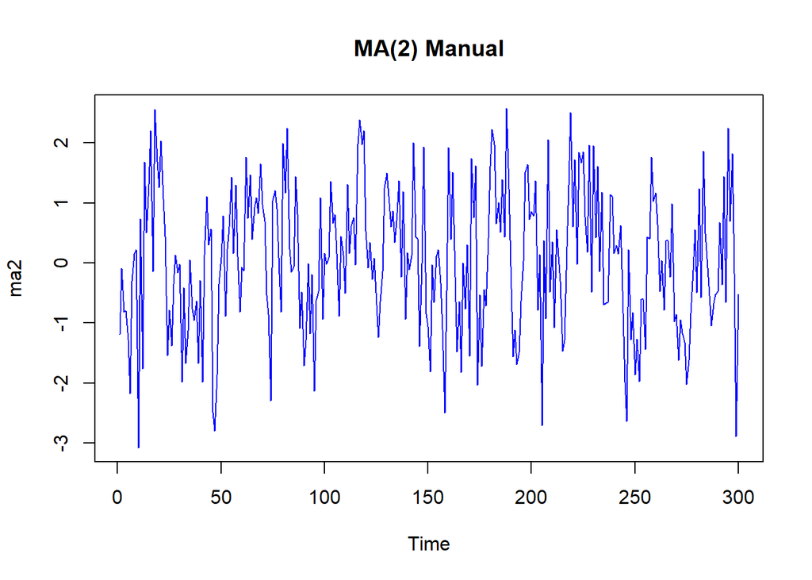

```r
# MA (2) Manual
ts.plot(ma2, main="MA(2) Manual", col="blue")
```

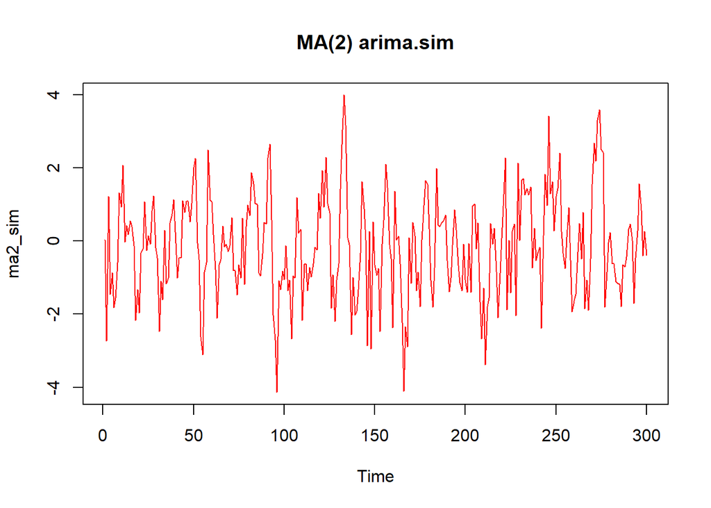

```r
# MA (2) fungsi arima.sim
ts.plot(ma2_sim, main="MA(2) arima.sim", col="red")
```

## Plot ACF dan PACF

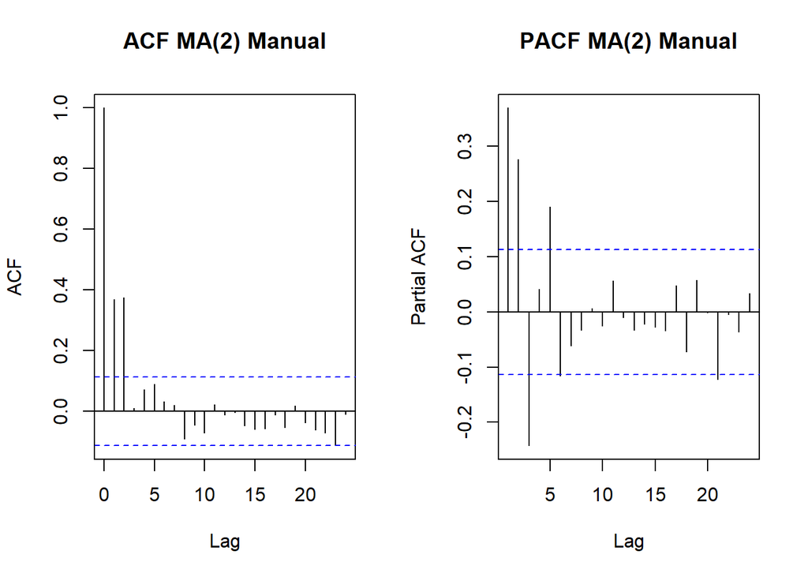

```r
# ACF dan PACF MA(2) Manual
par(mfrow=c(1,2))
acf(ma2, main="ACF MA(2) Manual")
pacf(ma2, main="PACF MA(2) Manual")
```

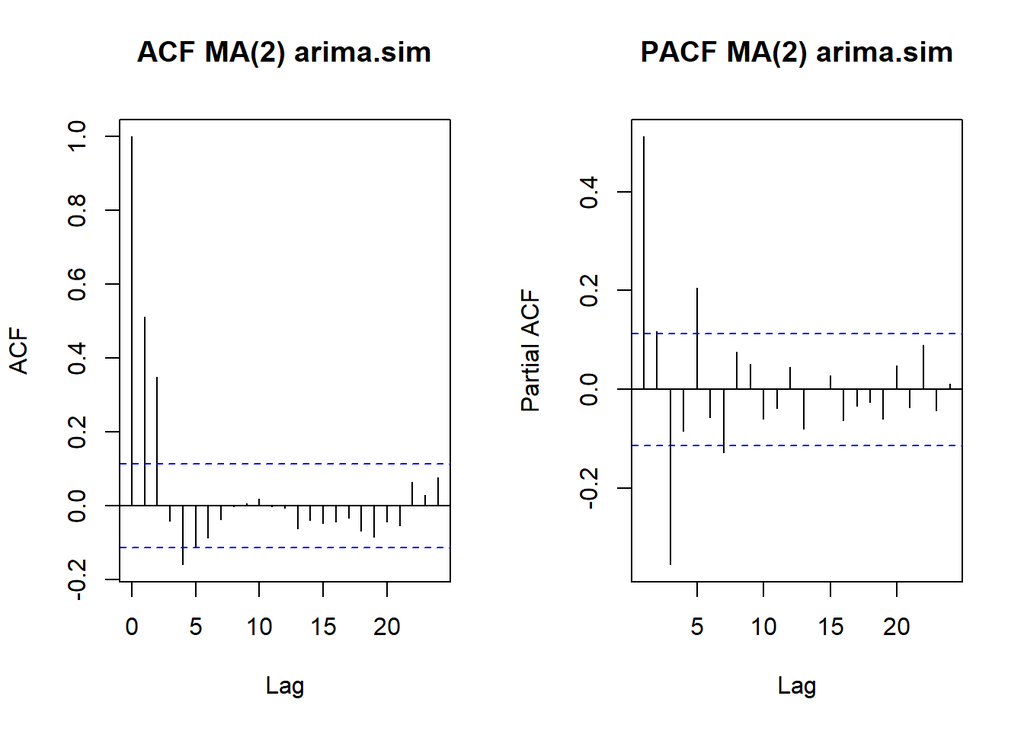

```r
# ACF dan PACF MA(2) arima.sim
par(mfrow=c(1,2))
acf(ma2_sim, main="ACF MA(2) arima.sim")
pacf(ma2_sim, main="PACF MA(2) arima.sim")
```

Dari plot ACF, terlihat kedua model ma(2) baik yang manual maupun fungsi arima.sim sama-sama cuts off di lag 2, sedangkan pada plot PACF menunjukkan pola yang cenderung tails off. Hal ini mengindikasikan bahwa model merupakan moving average dengan q=2 sehingga model ini merupakan model yang stasioner.

## Plot EACF

```r
# EACF MA(2) Manual
TSA::eacf(ma2)
```

```
## AR/MA
##   0 1 2 3 4 5 6 7 8 9 10 11 12 13
## 0 x x o o o o o o o o o  o  o  o
## 1 x x o o o o o o o o o  o  o  o
## 2 x x x x o o o x o o o  o  o  o
## 3 x x x o x o o o o o o  o  o  o
## 4 x x x o x x o o o o o  o  o  o
## 5 x x x x x x o o o o o  o  o  o
## 6 x o x o x x o o o o o  o  o  o
## 7 x x o o x x o o x o o  o  o  o
```

```r
# EACF MA(2) arima.sim
TSA::eacf(ma2_sim)
```

```
## AR/MA
##   0 1 2 3 4 5 6 7 8 9 10 11 12 13
## 0 x x o x o o o o o o o  o  o  o
## 1 x x o x o o o o o o o  o  o  o
## 2 x x x x o o o o o o o  o  o  o
## 3 x x x x x o o o o o o  o  o  o
## 4 x x x o o o o o o o o  o  o  o
## 5 x x x x o o o o o o o  o  o  o
## 6 x x x x o o o o o o o  o  o  o
## 7 x x o o o o o o o o o  o  o  o
```

## Scatterplot antar Lag

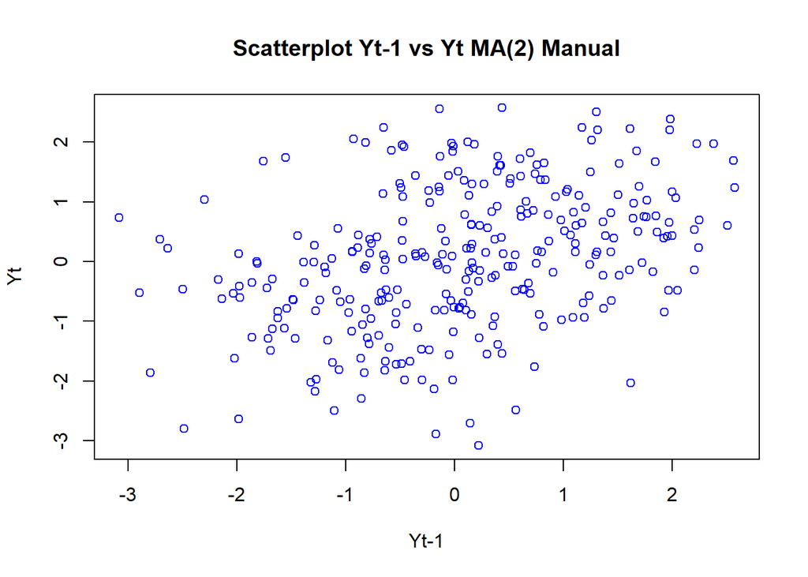

```r
# Scatterplot Autokorelasi MA(2) Manual

## Yt-1 vs Yt
yt1.ma2 <- ma2[-length(ma2)]
plot(y=ma2[-1], x=yt1.ma2, main="Scatterplot Yt-1 vs Yt MA(2) Manual",col="blue",xlab="Yt-1",ylab="Yt")
```

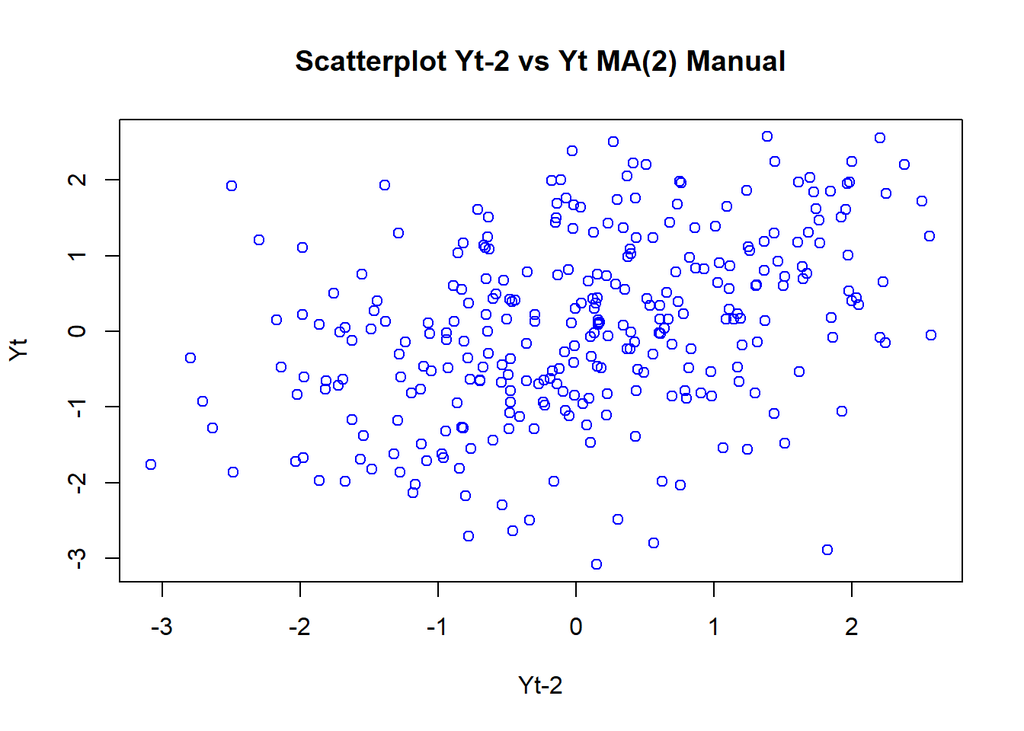

```r
## Yt-2 vs Yt
yt2.ma2 <- ma2[-c(length(ma2), length(ma2)-1)]
plot(y=ma2[-c(1,2)], x=yt2.ma2, main="Scatterplot Yt-2 vs Yt MA(2) Manual",col="blue",xlab="Yt-2",ylab="Yt")
```

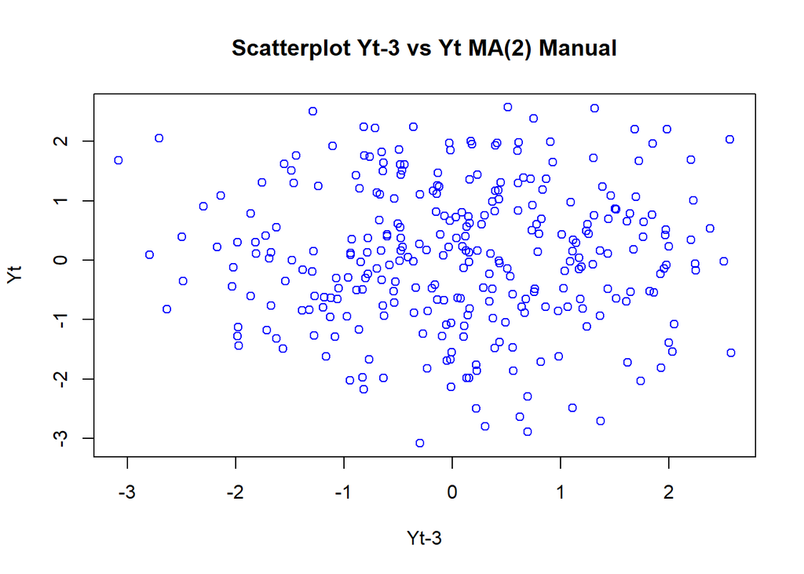

```r
## Yt-3 vs Yt
yt3.ma2 <- ma2[-c(length(ma2), length(ma2)-1, length(ma2)-2)]
plot(y=ma2[-c(1,2,3)], x=yt3.ma2, main="Scatterplot Yt-3 vs Yt MA(2) Manual",col="blue",xlab="Yt-3",ylab="Yt")
```

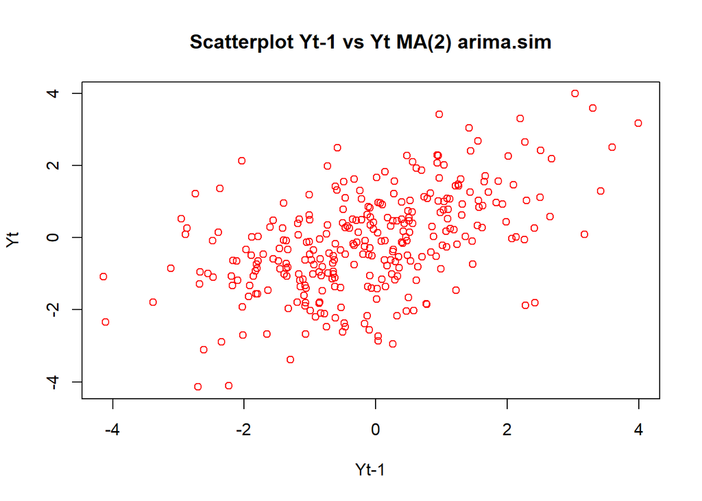

```r
# Scatterplot Autokorelasi MA(2) arima.sim

## Yt-1 vs Yt
yt1.ma2_sim <- ma2_sim[-length(ma2_sim)]
plot(y=ma2_sim[-1], x=yt1.ma2_sim, main="Scatterplot Yt-1 vs Yt MA(2) arima.sim",col="red",xlab="Yt-1",ylab="Yt")
```

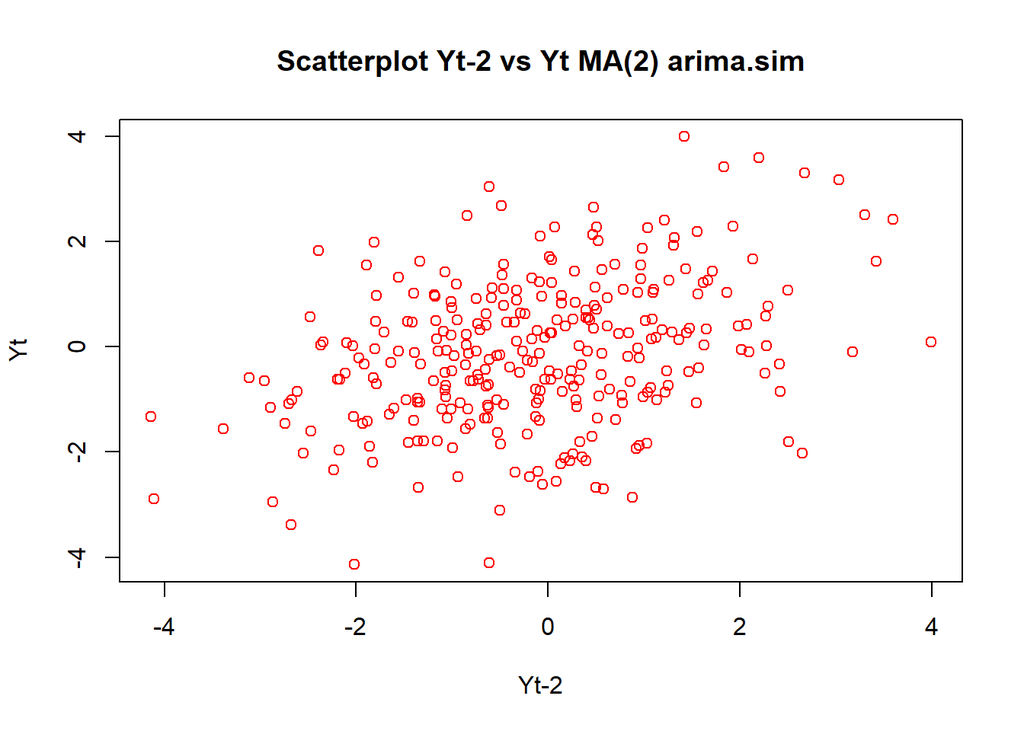

```r
## Yt-2 vs Yt
yt2.ma2_sim <- ma2_sim[-c(length(ma2_sim), length(ma2_sim)-1)]
plot(y=ma2_sim[-c(1,2)], x=yt2.ma2_sim, main="Scatterplot Yt-2 vs Yt MA(2) arima.sim",col="red",xlab="Yt-2",ylab="Yt")
```

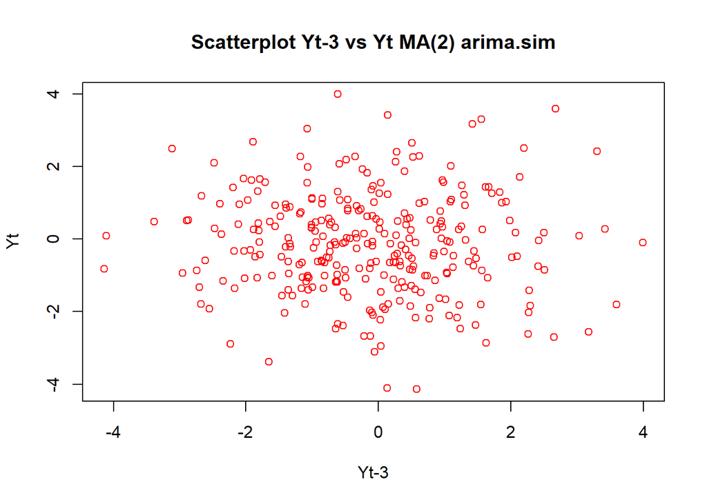

```r
## Yt-3 vs Yt
yt3.ma2_sim <- ma2_sim[-c(length(ma2_sim), length(ma2_sim)-1, length(ma2_sim)-2)]
plot(y=ma2_sim[-c(1,2,3)], x=yt3.ma2_sim, main="Scatterplot Yt-3 vs Yt MA(2) arima.sim",col="red",xlab="Yt-3",ylab="Yt")
```

Kedua model MA(2) baik yang manual maupun fungsi arima.sim menunjukkan pola yang cenderung positif linier pada lag 1 dan 2 yang mengindikasikan adanya autokorelasi positif, sementara cenderung tidak berkorelasi pada lag 3.

## Autokorelasi Data vs Teoretis

```r
# Autokorelasi MA(2) Manual
cat("Autokorelasi MA(2) Manual\n")
```

```
## Autokorelasi MA(2) Manual
```

```r
# Yt-Yt-1
cat("rho_1 =", cor(ma2[-1], yt1.ma2), "\n")
```

```
## rho_1 = 0.370312
```

```r
# Yt-Yt-2
cat("rho_2 =",cor(ma2[-c(1,2)], yt2.ma2), "\n")
```

```
## rho_2 = 0.3801094
```

```r
# Yt-Yt-3
cat("rho_3 =",cor(ma2[-c(1,2,3)], yt3.ma2), "\n")
```

```
## rho_3 = 0.009367813
```

```r
# Autokorelasi MA(2) arima.sim
cat("\nAutokorelasi MA(2) arima.sim\n")
```

```
##
## Autokorelasi MA(2) arima.sim
```

```r
# Yt-Yt-1
cat("rho_1 =", cor(ma2_sim[-1], yt1.ma2_sim), "\n")
```

```
## rho_1 = 0.5112622
```

```r
# Yt-Yt-2
cat("rho_2 =",cor(ma2_sim[-c(1,2)], yt2.ma2_sim), "\n")
```

```
## rho_2 = 0.3503734
```

```r
# Yt-Yt-3
cat("rho_3 =",cor(ma2_sim[-c(1,2,3)], yt3.ma2_sim), "\n")
```

```
## rho_3 = -0.0412263
```

Autokorelasi teoretis:
$$\rho_1 =
\frac{-\theta_1+\theta_1\theta_2}{1+{(-\theta_1)^2}+{(-\theta_2)^2}} =
\frac{-(-0.4)+(-0.4)(-0.6)}{1+(-0.4)^2+(-0.6)^2} \approx 0.421$$

$$\rho_2 =
\frac{-\theta_2}{1+{(-\theta_1)^2}+{(-\theta_2)^2}} =
\frac{-(-0.6)}{1+(-0.4)^2+(-0.6)^2} \approx 0.395$$

$$\rho_k = 0, k>2$$

# AR(2)

## Pembangkitan Data

```r
# AR(2) Manual
set.seed(1069)
ar2<-numeric(300)
ar2[c(1,2)]<-1

for(i in 3:300){
  ar2[i]<-0.5*ar2[i-1]+0.2*ar2[i-2]+white[i]
}
ar2
```

```
##   [1]  1.000000000  1.000000000  0.635128757 -0.200268917 -0.926443968
##   [6] -1.864034754 -0.303087885  0.116493473 -0.528301192 -3.497547223
##  [11]  0.498330293 -1.196330254  0.070054498  0.521588884  0.953465654
##  [16]  2.076370630  0.083128978  2.577475893  2.838104472  1.308768988
##  [21]  2.581786064  2.448249353  1.004089247 -0.790833577  0.174281555
##  [26] -0.529459214 -0.626039671  0.145736328 -0.204413292 -0.367834456
##  [31] -1.995656606 -0.598649507 -1.496791694 -1.960215271 -0.316230982
##  [36] -1.051161948 -1.925871423 -0.976564157 -1.821543910 -1.142202657
##  [41] -2.336342936 -0.682688511  0.855881908 -0.501036039 -0.200660408
##  [46] -2.161637972 -3.061127083 -1.870128815 -0.773882264 -1.035218834
##  [51] -0.247333846 -1.225762467 -0.330786471  0.597772117  1.063441533
##  [56] -0.124665273  1.256654001  0.731139310 -0.909747602  0.154447031
##  [61]  0.491309626  1.521014550  0.742366928  1.438481088  1.025220011
##  [66]  1.207433824  1.640859031  1.308309108  2.028869641  1.685593785
##  [71]  1.153025042  0.171449263 -0.185371145 -1.710130419  1.109085012
```

[output cut: 45 more lines]

```r
# AR(2) dengan fungsi arima.sim
ar2_sim <- arima.sim(list(order=c(2,0,0), ar=c(0.5,0.2)), n=300)
ar2_sim
```

```
## Time Series:
## Start = 1
## End = 300
## Frequency = 1
##   [1] -0.531959221 -0.627945545  0.144283389 -0.205520936 -0.368678866
##   [6] -1.996300339 -0.599140256 -1.497165815 -1.960500481 -0.316448412
##  [11] -1.051327705 -1.925997787 -0.976660491 -1.821617350 -1.142258643
##  [16] -2.336385618 -0.682721049  0.855857103 -0.501054949 -0.200674825
##  [21] -2.161648962 -3.061135461 -1.870135203 -0.773887134 -1.035222546
##  [26] -0.247336675 -1.225764624 -0.330788116  0.597770863  1.063440578
##  [31] -0.124666002  1.256653446  0.731138886 -0.909747925  0.154446785
##  [36]  0.491309439  1.521014407  0.742366819  1.438481005  1.025219947
##  [41]  1.207433776  1.640858995  1.308309079  2.028869619  1.685593768
##  [46]  1.153025030  0.171449254 -0.185371153 -1.710130425  1.109085008
##  [51]  1.606994255  0.173780703 -0.266847109 -0.136088802  2.293741915
```

[output cut: 49 more lines]

## Plot time series

[figure not shown]

```r
# AR (2) Manual
ts.plot(ar2, main="MA(2) Manual", col="blue")
```

[figure not shown]

```r
# AR (2) fungsi arima.sim
ts.plot(ar2_sim, main="MA(2) arima.sim", col="red")
```

## Plot ACF dan PACF

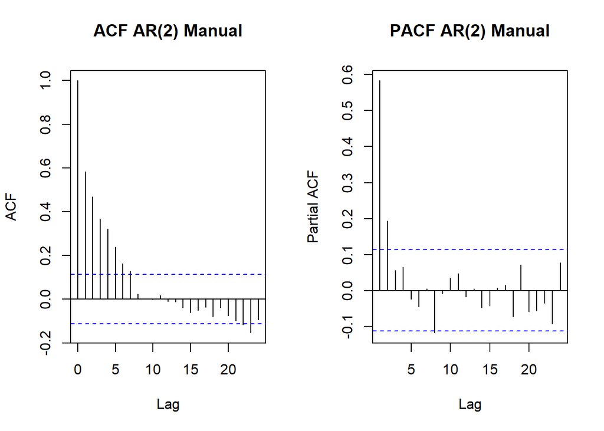

```r
# ACF dan PACF AR(2) Manual
par(mfrow=c(1,2))
acf(ar2, main="ACF AR(2) Manual")
pacf(ar2, main="PACF AR(2) Manual")
```

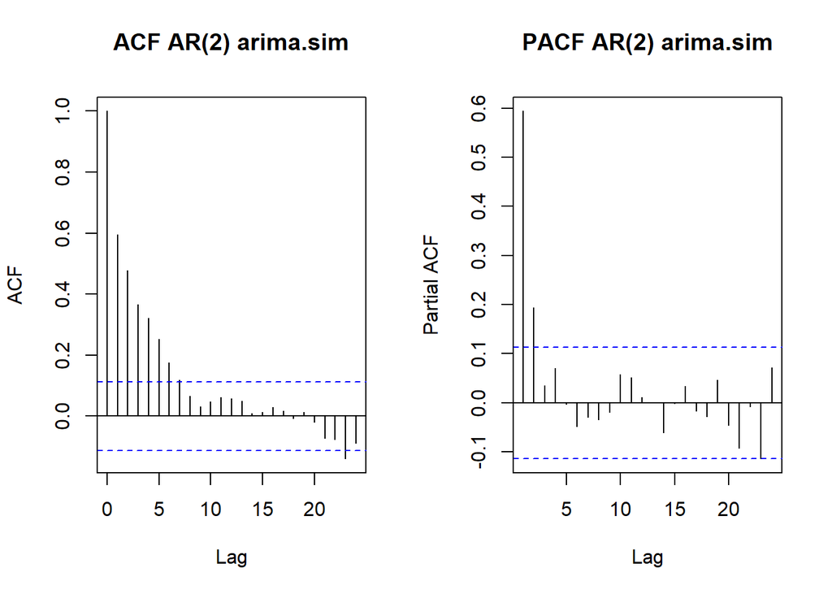

```r
# ACF dan PACF Ar(2) arima.sim
par(mfrow=c(1,2))
acf(ar2_sim, main="ACF AR(2) arima.sim")
pacf(ar2_sim, main="PACF AR(2) arima.sim")
```

Dari plot ACF, terlihat kedua model ar(2) baik yang manual maupun fungsi arima.sim sama-sama tails off, sedangkan pada plot PACF menunjukkan pola yang cuts off di lag 2. Hal ini mengindikasikan bahwa model merupakan autoregressive dengan p=2 sehingga model ini merupakan model yang stasioner.

## Plot EACF

```r
# EACF Ar(2) Manual
TSA::eacf(ar2)
```

```
## AR/MA
##   0 1 2 3 4 5 6 7 8 9 10 11 12 13
## 0 x x x x x x x o o o o  o  o  o
## 1 x o o o o o x o o o o  o  o  o
## 2 x o o o o o x o o o o  o  o  o
## 3 x x o o o o x o o o o  o  o  o
## 4 x x o x o o x o o o o  o  o  o
## 5 x x o x o o x o o o o  o  o  o
## 6 o x x x o o x o o o o  o  o  o
## 7 o x x x x x x o o o o  o  o  o
```

```r
# EACF AR(2) arima.sim
TSA::eacf(ar2_sim)
```

```
## AR/MA
##   0 1 2 3 4 5 6 7 8 9 10 11 12 13
## 0 x x x x x x x o o o o  o  o  o
## 1 x o o o o o o o o o o  o  o  o
## 2 x x o o o o o o o o o  o  o  o
## 3 x x x o o o o o o o o  o  o  o
## 4 o x o o o o o o o o o  o  o  o
## 5 o x o x o o o o o o o  o  o  o
## 6 x x x x o o o o o o o  o  o  o
## 7 x x o x x o o o o o o  o  o  o
```

## Scatterplot antar Lag

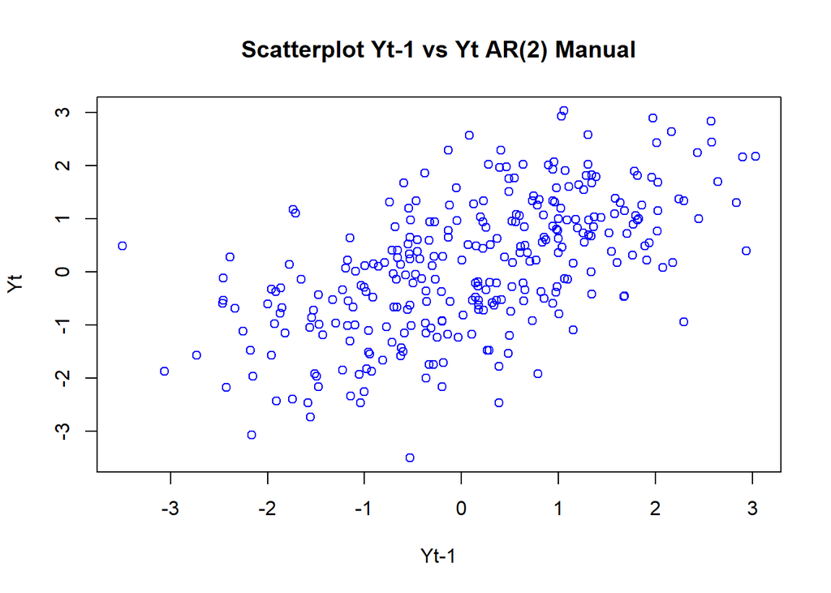

```r
# Scatterplot Autokorelasi AR(2) Manual

## Yt-1 vs Yt
yt1.ar2 <- ar2[-length(ar2)]
plot(y=ar2[-1], x=yt1.ar2, main="Scatterplot Yt-1 vs Yt AR(2) Manual",col="blue",xlab="Yt-1",ylab="Yt")
```

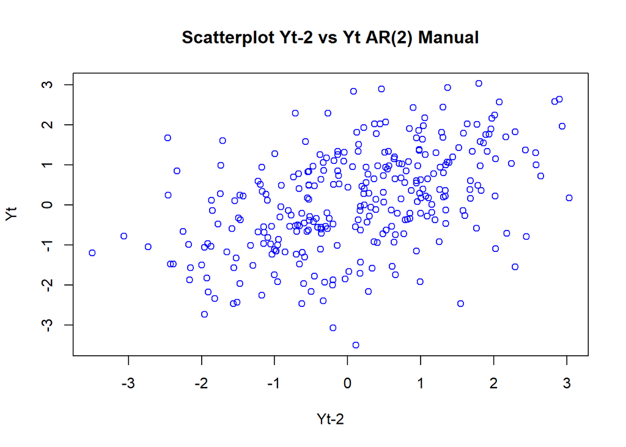

```r
## Yt-2 vs Yt
yt2.ar2 <- ar2[-c(length(ar2), length(ar2)-1)]
plot(y=ar2[-c(1,2)], x=yt2.ar2, main="Scatterplot Yt-2 vs Yt AR(2) Manual",col="blue",xlab="Yt-2",ylab="Yt")
```

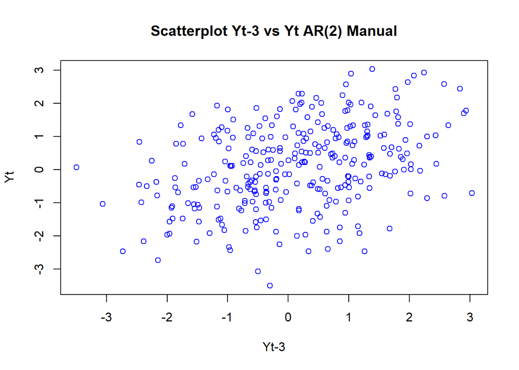

```r
## Yt-3 vs Yt
yt3.ar2 <- ar2[-c(length(ar2), length(ar2)-1, length(ar2)-2)]
plot(y=ar2[-c(1,2,3)], x=yt3.ar2, main="Scatterplot Yt-3 vs Yt AR(2) Manual",col="blue",xlab="Yt-3",ylab="Yt")
```